# Bikeshare Data - Exploration and Data Findings Communication Project

## Introduction

Bluebikes is Metro Boston's public bike share program, with more than 1,800 bikes at over 200 stations across Boston, Brookline, Cambridge and Somerville. Bluebikes is owned by the municipalities of Boston, Brookline, Cambridge and Somerville, and operated by Motivate.

Boston's original bike share program, Hubway, launched in 2011 and quickly became an essential part of our transportation network as a fun, efficient and affordable way to get around. In 2018, Blue Cross Blue Shield of Massachusetts became the title sponsor for the system and the name was changed to Bluebikes.

Bluebikes, like other bike share systems, consists of a fleet of specially designed, sturdy and durable bikes that are locked into a network of docking stations throughout the city. The bikes can be unlocked from one station and returned to any other station in the system, making them ideal for one-way trips. People use bike share to commute to work or school, run errands, get to appointments or social engagements, and more. Reference: "https://www.bluebikes.com/about"

The data set details can be found on the official website at https://www.bluebikes.com/system-data as separate zip files for each year month, I've selected and downloaded the compressed data files for 24 months from Jan, 2018 to Dec, 2019. The original compressed files can be found here https://s3.amazonaws.com/hubway-data/index.html.

I've decompressed the individual files, combined them into one 'csv' file to start working with. A compressed version of it is available here https://www.dropbox.com/s/ztdvsrr67o1y15g/boston_2018_2019.zip?dl=0.

In this analysis, I was interested in answering the following questions: -

- How much Bluebikes has grown in 2019 in compare to 2018?
- What factors affetcs trips duration?

## Preliminary Wrangling

```python
# import all packages and set plots to be embedded inline
import numpy as np
import pandas as pd
import matplotlib.pyplot as plt
import seaborn as sb
from os import listdir

%matplotlib inline
```

```python
df = pd.read_csv('boston_2018_2019.csv', index_col=0)
```

### The structure of the dataset

> The data includes:
> - Trip Duration (seconds)
> - Start Time and Date
> - Stop Time and Date
> - Start Station Name & ID
> - End Station Name & ID
> - Bike ID
> - User Type (Casual = Single Trip or Day Pass user; Member = Annual or Monthly Member)
> - Birth Year
> - Gender, self-reported by member

### The main features of interest in the dataset

> - Trip Duration (seconds)
> - Bike ID
> - Start Station Name
> - End Station Name

### Features in the dataset that I think will help support the investigation into features of interest

> - Start Time and Date
> - Stop Time and Date
> - User Type
> - Birth Year
> - Gender

### Assessment

```python
df.head()
```

|  | tripduration | starttime | stoptime | start station id | start station name | start station latitude | start station longitude | end station id | end station name | end station latitude | end station longitude | bikeid | usertype | birth year | gender |
| --- | --- | --- | --- | --- | --- | --- | --- | --- | --- | --- | --- | --- | --- | --- | --- |
| 0 | 916 | 2019-09-01 00:00:21.2560 | 2019-09-01 00:15:38.0670 | 9 | Commonwealth Ave at Agganis Way | 42.351692 | -71.119035 | 33 | Kenmore Square | 42.348706 | -71.097009 | 4161 | Subscriber | 2000.0 | 1 |
| 1 | 394 | 2019-09-01 00:00:33.0140 | 2019-09-01 00:07:07.1410 | 189 | Kendall T | 42.362428 | -71.084955 | 178 | MIT Pacific St at Purrington St | 42.359573 | -71.101295 | 5515 | Subscriber | 1991.0 | 1 |
| 2 | 480 | 2019-09-01 00:00:52.4870 | 2019-09-01 00:08:52.9530 | 9 | Commonwealth Ave at Agganis Way | 42.351692 | -71.119035 | 10 | B.U. Central - 725 Comm. Ave. | 42.350406 | -71.108279 | 3061 | Customer | 1969.0 | 0 |
| 3 | 800 | 2019-09-01 00:01:05.5390 | 2019-09-01 00:14:25.8490 | 46 | Christian Science Plaza - Massachusetts Ave at... | 42.343666 | -71.085824 | 199 | Upham's Corner T Stop - Magnolia St at Dudley St | 42.318697 | -71.069781 | 3309 | Subscriber | 1983.0 | 1 |
| 4 | 758 | 2019-09-01 00:01:13.4250 | 2019-09-01 00:13:52.2810 | 56 | Dudley Square - Dudley St at Warren St | 42.329843 | -71.083866 | 55 | Boylston St at Massachusetts Ave | 42.347265 | -71.088088 | 743 | Subscriber | 1977.0 | 1 |

```python
df.info()
```

```
<class 'pandas.core.frame.DataFrame'>
Int64Index: 4290343 entries, 0 to 205358
Data columns (total 15 columns):
 #   Column                   Dtype
---  ------                   -----
 0   tripduration             int64
 1   starttime                object
 2   stoptime                 object
 3   start station id         int64
 4   start station name       object
 5   start station latitude   float64
 6   start station longitude  float64
 7   end station id           int64
 8   end station name         object
 9   end station latitude     float64
 10  end station longitude    float64
 11  bikeid                   int64
 12  usertype                 object
 13  birth year               float64
 14  gender                   int64
dtypes: float64(5), int64(5), object(5)
memory usage: 523.7+ MB
```

```python
df.duplicated().sum()
```

```
0
```

```python
df.isnull().sum()
```

```
tripduration                  0
starttime                     0
stoptime                      0
start station id              0
start station name            0
start station latitude        0
start station longitude       0
end station id                0
end station name              0
end station latitude          0
end station longitude         0
bikeid                        0
usertype                      0
birth year                 9592
gender                        0
dtype: int64
```

**Issues found**

- Unnecessary columns need to be dropped, `start station id`, `start station latitude`, `start station longitude`, `end station id`, `end station latitude` and `end station longitude`.
- Rows with null values in `birth year` should be dropped.
- Columns `starttime` and `stoptime` should be converted to `datetime` format, `birth year` to `int`, `bikeid` to str and gender values should be replaced by corresponding gender string.
- Columns names should be renamed for easy access.

**Features to be engineered**

- `year` for year of the record as of type int.
- `month` for month of the record as str of corresponding month.
- `day_of_week` as a str of the week day of the record.
- `day_hour` as a str of the day hour of the record.
- `user_age` as of type int of the user age at the time of the record.

### Cleaning

#### Code

```python
# Dropping unnecessary columns
df = df.drop(columns=['start station id', 'start station latitude', 'start station longitude', 'end station id', 'end station latitude', 'end station longitude'])
```

```python
# Dropping rows with null values in 'birth year'
df = df.drop(df[df['birth year'].isnull()].index, axis=0)
```

```python
# Converting starttime and stoptime columns to type datetime
df[['starttime', 'stoptime']] = df[['starttime', 'stoptime']].apply(pd.to_datetime)
```

```python
# Converting birth year to int and bikeid to str
df['birth year'] = df['birth year'].astype(int)
df['bikeid'] = df['bikeid'].astype(str)
```

```python
# Replacing gender values with corresponding gender string
# (Zero=unknown; 1=male; 2=female)
# The values reference is from an identically structured data set avaialble here https://www.citibikenyc.com/system-data

df.loc[df['gender'] == 0, 'gender'] = 'Unknown'
df.loc[df['gender'] == 1, 'gender'] = 'Male'
df.loc[df['gender'] == 2, 'gender'] = 'Female'
```

```python
# Renaming columns
columns = {
    'tripduration': 'trip_duration',
    'starttime': 'start_time',
    'stoptime': 'end_time',
    'start station name': 'start_station',
    'end station name': 'end_station',
    'bikeid': 'bike_id',
    'usertype': 'user_type',
    'birth year': 'user_birth_year',
    'gender': 'gender'
}
df.rename(columns=columns, inplace=True)
```

#### Test

```python
df.info()
```

```
<class 'pandas.core.frame.DataFrame'>
Int64Index: 4074778 entries, 1 to 205358
Data columns (total 9 columns):
 #   Column           Dtype
---  ------           -----
 0   trip_duration    int64
 1   start_time       datetime64[ns]
 2   end_time         datetime64[ns]
 3   start_station    object
 4   end_station      object
 5   bike_id          object
 6   user_type        object
 7   user_birth_year  int64
 8   gender           object
dtypes: datetime64[ns](2), int64(2), object(5)
memory usage: 310.9+ MB
```

```python
df.isnull().sum()
```

```
trip_duration      0
start_time         0
end_time           0
start_station      0
end_station        0
bike_id            0
user_type          0
user_birth_year    0
gender             0
dtype: int64
```

```python
df.gender.value_counts()
```

```
Male       2657481
Female      943874
Unknown     473423
Name: gender, dtype: int64
```

### Feature Engineering

```python
# Adding trip_year column of type int
df['trip_year'] = df.start_time.dt.year.astype(str)
```

```python
# Adding trip_month column of type str
df['trip_month'] = df.start_time.dt.month_name()
```

```python
# Adding trip_day column of type str
df['trip_day'] = df.start_time.dt.day_name()
```

```python
# Adding trip_hour column of type str
df['trip_hour'] = df.start_time.dt.hour.astype(str)
```

```python
# Adding user_age column of type int which represents the user age at the time of the record
df['user_age'] = df.trip_year.astype(int) - df.user_birth_year
```

```python
df.head()
```

|  | trip_duration | start_time | end_time | start_station | end_station | bike_id | user_type | user_birth_year | gender | trip_year | trip_month | trip_day | trip_hour | user_age |
| --- | --- | --- | --- | --- | --- | --- | --- | --- | --- | --- | --- | --- | --- | --- |
| 1 | 394 | 2019-09-01 00:00:33.014 | 2019-09-01 00:07:07.141 | Kendall T | MIT Pacific St at Purrington St | 5515 | Subscriber | 1991 | Male | 2019 | September | Sunday | 0 | 28 |
| 2 | 480 | 2019-09-01 00:00:52.487 | 2019-09-01 00:08:52.953 | Commonwealth Ave at Agganis Way | B.U. Central - 725 Comm. Ave. | 3061 | Customer | 1969 | Unknown | 2019 | September | Sunday | 0 | 50 |
| 3 | 800 | 2019-09-01 00:01:05.539 | 2019-09-01 00:14:25.849 | Christian Science Plaza - Massachusetts Ave at... | Upham's Corner T Stop - Magnolia St at Dudley St | 3309 | Subscriber | 1983 | Male | 2019 | September | Sunday | 0 | 36 |
| 4 | 758 | 2019-09-01 00:01:13.425 | 2019-09-01 00:13:52.281 | Dudley Square - Dudley St at Warren St | Boylston St at Massachusetts Ave | 743 | Subscriber | 1977 | Male | 2019 | September | Sunday | 0 | 42 |
| 5 | 261 | 2019-09-01 00:01:33.778 | 2019-09-01 00:05:55.556 | Curtis Hall - South St at Centre St | Forest Hills | 3241 | Subscriber | 1989 | Female | 2019 | September | Sunday | 0 | 30 |

```python
df.info()
```

```
<class 'pandas.core.frame.DataFrame'>
Int64Index: 4074778 entries, 1 to 205358
Data columns (total 14 columns):
 #   Column           Dtype
---  ------           -----
 0   trip_duration    int64
 1   start_time       datetime64[ns]
 2   end_time         datetime64[ns]
 3   start_station    object
 4   end_station      object
 5   bike_id          object
 6   user_type        object
 7   user_birth_year  int64
 8   gender           object
 9   trip_year        object
 10  trip_month       object
 11  trip_day         object
 12  trip_hour        object
 13  user_age         int64
dtypes: datetime64[ns](2), int64(3), object(9)
memory usage: 466.3+ MB
```

```python
# Creating a clean_df with columns re-arranged for easy interpretation
clean_df = df[['start_time', 'end_time',
               'trip_year', 'trip_month', 'trip_day', 'trip_hour', 'trip_duration',
               'start_station', 'end_station',
               'bike_id',
               'user_type', 'gender', 'user_age', 'user_birth_year']]
```

```python
clean_df.head()
```

|  | start_time | end_time | trip_year | trip_month | trip_day | trip_hour | trip_duration | start_station | end_station | bike_id | user_type | gender | user_age | user_birth_year |
| --- | --- | --- | --- | --- | --- | --- | --- | --- | --- | --- | --- | --- | --- | --- |
| 1 | 2019-09-01 00:00:33.014 | 2019-09-01 00:07:07.141 | 2019 | September | Sunday | 0 | 394 | Kendall T | MIT Pacific St at Purrington St | 5515 | Subscriber | Male | 28 | 1991 |
| 2 | 2019-09-01 00:00:52.487 | 2019-09-01 00:08:52.953 | 2019 | September | Sunday | 0 | 480 | Commonwealth Ave at Agganis Way | B.U. Central - 725 Comm. Ave. | 3061 | Customer | Unknown | 50 | 1969 |
| 3 | 2019-09-01 00:01:05.539 | 2019-09-01 00:14:25.849 | 2019 | September | Sunday | 0 | 800 | Christian Science Plaza - Massachusetts Ave at... | Upham's Corner T Stop - Magnolia St at Dudley St | 3309 | Subscriber | Male | 36 | 1983 |
| 4 | 2019-09-01 00:01:13.425 | 2019-09-01 00:13:52.281 | 2019 | September | Sunday | 0 | 758 | Dudley Square - Dudley St at Warren St | Boylston St at Massachusetts Ave | 743 | Subscriber | Male | 42 | 1977 |
| 5 | 2019-09-01 00:01:33.778 | 2019-09-01 00:05:55.556 | 2019 | September | Sunday | 0 | 261 | Curtis Hall - South St at Centre St | Forest Hills | 3241 | Subscriber | Female | 30 | 1989 |

```python
clean_df.info()
```

```
<class 'pandas.core.frame.DataFrame'>
Int64Index: 4074778 entries, 1 to 205358
Data columns (total 14 columns):
 #   Column           Dtype
---  ------           -----
 0   start_time       datetime64[ns]
 1   end_time         datetime64[ns]
 2   trip_year        object
 3   trip_month       object
 4   trip_day         object
 5   trip_hour        object
 6   trip_duration    int64
 7   start_station    object
 8   end_station      object
 9   bike_id          object
 10  user_type        object
 11  gender           object
 12  user_age         int64
 13  user_birth_year  int64
dtypes: datetime64[ns](2), int64(3), object(9)
memory usage: 466.3+ MB
```

## Univariate Exploration

```python
clean_df.trip_year.shape
```

```
(4074778,)
```

```python
clean_df.groupby('trip_year').count()
```

| trip_year | start_time | end_time | trip_month | trip_day | trip_hour | trip_duration | start_station | end_station | bike_id | user_type | gender | user_age | user_birth_year |
| --- | --- | --- | --- | --- | --- | --- | --- | --- | --- | --- | --- | --- | --- |
| 2018 | 1662149 | 1662149 | 1662149 | 1662149 | 1662149 | 1662149 | 1662149 | 1662149 | 1662149 | 1662149 | 1662149 | 1662149 | 1662149 |
| 2019 | 2412629 | 2412629 | 2412629 | 2412629 | 2412629 | 2412629 | 2412629 | 2412629 | 2412629 | 2412629 | 2412629 | 2412629 | 2412629 |

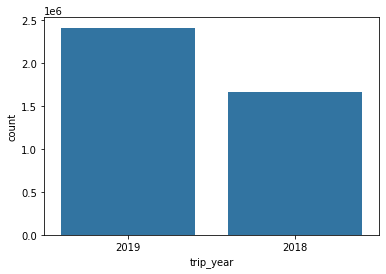

```python
# trip_year absolute count
base_color = sb.color_palette()[0]
sb.countplot(data = clean_df, x = 'trip_year', color=base_color);
```

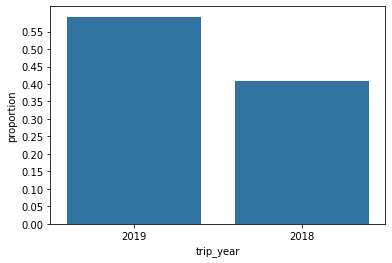

```python
# trip_year proportional
n_points = clean_df.shape[0]
max_count = clean_df.trip_year.value_counts().max()
max_prop = max_count / n_points

tick_props = np.arange(0, max_prop, 0.05)
tick_names = ['{:0.2f}'.format(v) for v in tick_props]

sb.countplot(data = clean_df, x = 'trip_year', color = base_color)
plt.yticks(tick_props * n_points, tick_names)
plt.ylabel('proportion');
```

```python
# Growth rate in 2019
(clean_df.trip_year.value_counts()[0]/clean_df.trip_year.value_counts()[1]) - 1
```

```
0.45151186806958954
```

**Total count of trips increased significantly in 2019 in compare to 2018 with a total growth nearly equal to 45 %**

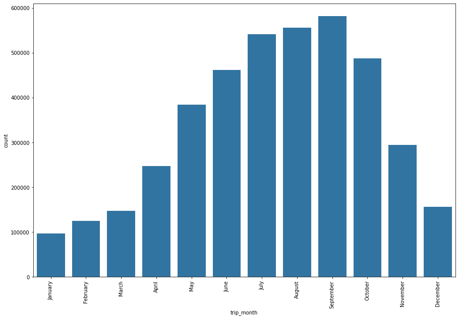

```python
# trip_month
months_order = ['January', 'February', 'March', 'April', 'May', 'June', 'July',
                'August', 'September', 'October', 'November', 'December']
ordered_months = pd.api.types.CategoricalDtype(ordered = True, categories = months_order)
clean_df.trip_month = clean_df.trip_month.astype(ordered_months)

fig = plt.figure(figsize=(15, 10))
ax = fig.add_axes([.125, .125, .775, .755])
sb.countplot(data = clean_df, x = 'trip_month', color=base_color);
plt.xticks(rotation=90);
```

**The total monthly trips shows unimodal distribution that peaks around summer months**

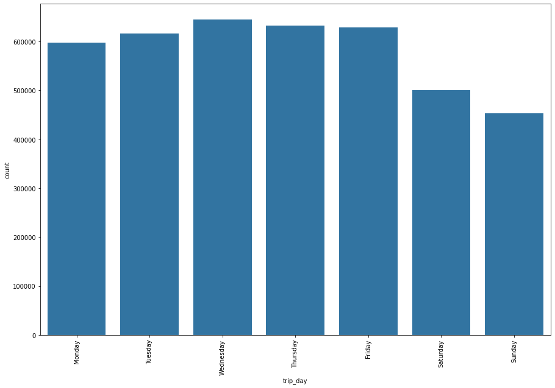

```python
# trip_day
days_order = ['Monday', 'Tuesday', 'Wednesday', 'Thursday', 'Friday', 'Saturday', 'Sunday']
ordered_days = pd.api.types.CategoricalDtype(ordered = True, categories = days_order)
clean_df.trip_day = clean_df.trip_day.astype(ordered_days)

fig = plt.figure(figsize=(15, 10))
ax = fig.add_axes([.125, .125, .775, .755])
sb.countplot(data = clean_df, x = 'trip_day', color=base_color);
plt.xticks(rotation=90);
```

**It was interesting to notice that there are no great variations in total daily trips count over week days except for slight decrease during weekends**

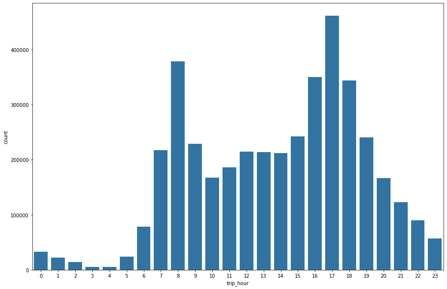

```python
# trip_hour
hours_order = ['0', '1', '2', '3', '4', '5', '6', '7', '8', '9', '10', '11',
               '12' , '13', '14' , '15', '16', '17', '18', '19', '20', '21', '22', '23']
ordered_hours = pd.api.types.CategoricalDtype(ordered = True, categories = hours_order)
clean_df.trip_hour = clean_df.trip_hour.astype(ordered_hours)

fig = plt.figure(figsize=(15, 10))
ax = fig.add_axes([.125, .125, .775, .755])
sb.countplot(data = clean_df, x = 'trip_hour', color=base_color);
# plt.xticks(rotation=90);
```

**There is bimodal distribution of trips over hours over the day with two peaks, the first is at the morning hours around 08:00 AM, and the second is at the evening hours around 05:00 PM**

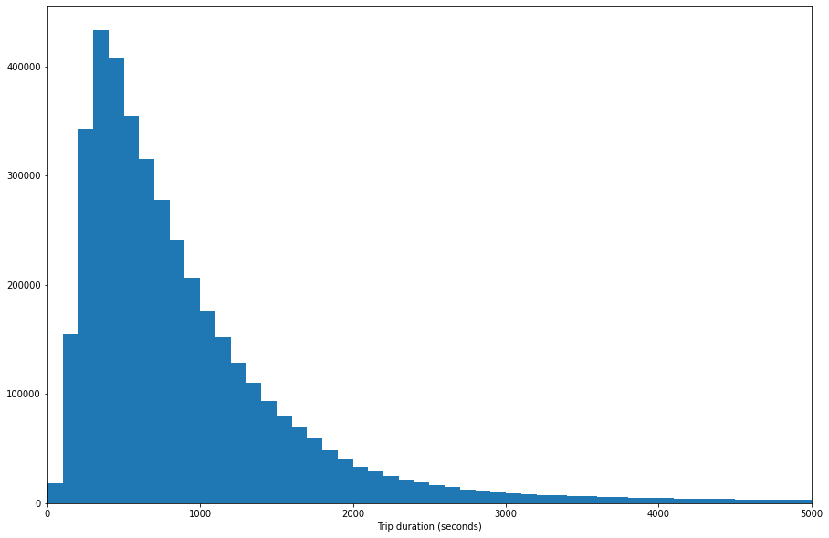

```python
# trip_duration
plt.figure(figsize=(15, 10));
bin_edges = np.arange(0, clean_df.trip_duration.max()+100, 100)
plt.hist(data=clean_df, x='trip_duration', bins=bin_edges);
plt.xlim(0, 5000);
plt.xlabel('Trip duration (seconds)');
```

```python
clean_df.trip_duration[clean_df.trip_duration <= 5000].describe()
```

```
count    4.003733e+06
mean     9.029329e+02
std      7.328455e+02
min      6.100000e+01
25%      4.110000e+02
50%      6.910000e+02
75%      1.147000e+03
max      5.000000e+03
Name: trip_duration, dtype: float64
```

**The trip durations shows right skewness with outliers detected for values over 5000 seconds, so the plot was zoomed in for values between 0 and 5000 seconds to better visualize and draw a conclusion about trips durations**

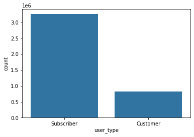

```python
# user_type
sb.countplot(data=clean_df, x='user_type', color=base_color);
```

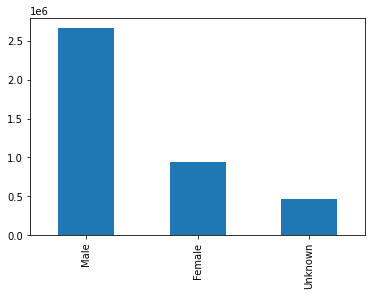

```python
# user_gender
clean_df.gender.value_counts().plot(kind='bar');
```

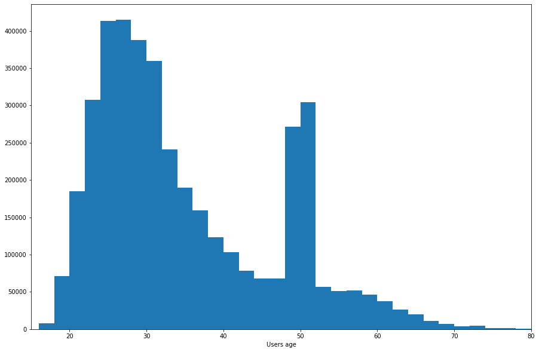

```python
# user_age
plt.figure(figsize=(15, 10))
bin_edges = np.arange(0, clean_df.user_age.max()+2, 2)
plt.hist(data=clean_df, x='user_age', bins=bin_edges);
plt.xlim(15, 80);
plt.xlabel('Users age');
```

```python
clean_df.user_age[clean_df.user_age > 80]
```

```
2894      115
8943      115
9181      115
10392      81
11287     115
         ...
198361    130
200977     89
201101     89
201185     89
202468     89
Name: user_age, Length: 1461, dtype: int64
```

```python
clean_df.user_age.describe()
```

```
count    4.074778e+06
mean     3.467658e+01
std      1.160713e+01
min      1.600000e+01
25%      2.600000e+01
50%      3.100000e+01
75%      4.400000e+01
max      1.550000e+02
Name: user_age, dtype: float64
```

- **When exploring the age distribution of users, outliers were detected above age of 80 with maximum value of 155 years! which doesn't make sense and may suggest faulty input of users birth year, so age values above 80 were excluded to better understand this variable**
- **Anonther interesting observation was that there was a surge in the age distribution around age of 50 years**

### Unusual distributions and data transformations

> - During the early assessment of data set, new features were engineered to give better exploration results through extracting each trip year, month, day of week and hour in the day and adding a new calculated feature of user age at the time of the trip.
> - The trip durations shows right skewness with outliers detected for values over 5000 seconds, so the plot was zoomed in for values between 0 and 5000 seconds to better visualize and draw a conclusion about trips durations.
> - When exploring the age distribution of users, outliers were detected above age of 80 with maximum value of 155 years! which doesn't make sense and may suggest faulty input of users birth year, so age values above 80 were excluded to better understand this variable.

## Bivariate Exploration

```python
# trip_hour vs trip_day
# The main idea of converting categorical variables to numerical ranks for easy plotting as a heatmap was adopted from similar plot at https://github.com/juliaYi/Ford-GoBike-Data-Visualization/blob/master/ford_bike_data_analysis.ipynb
trip_hour_day = clean_df.groupby(['trip_hour', 'trip_day']).agg({'bike_id' : 'count'}).rename(columns={'bike_id':'count'}).reset_index()
trip_hour_day.trip_day = pd.Categorical(trip_hour_day.trip_day, categories=['Monday', 'Tuesday', 'Wednesday', 'Thursday', 'Friday', 'Saturday', 'Sunday'], ordered=True)
trip_hour_day['percent'] = trip_hour_day['count'].apply(lambda x: (x/trip_hour_day['count'].sum())*100)
trip_hour_day['rank'] = trip_hour_day['percent'].rank(ascending=False).astype(int)
trip_hour_day_pivoted = trip_hour_day.pivot_table(index='trip_hour', columns='trip_day', values='rank')
```

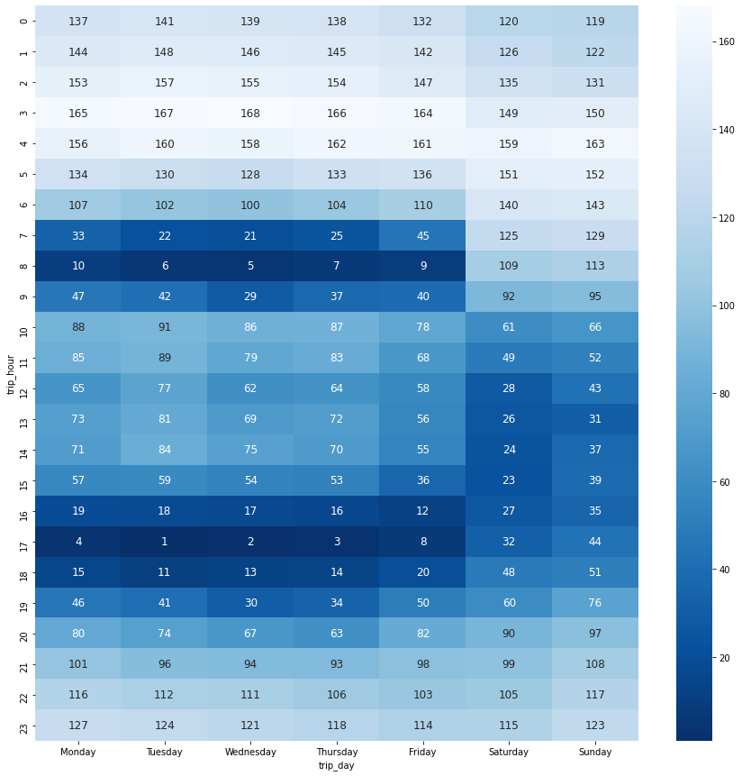

```python
fig = plt.figure(figsize=(15, 15))
ax = fig.add_axes([.125, .125, .775, .755])
sb.heatmap(trip_hour_day_pivoted, fmt='d', annot=True, cmap='Blues_r', annot_kws={"size": 12});
```

**The above heatmap shows that in normal days of the week, the most active hours are early morning "go to work" around 08:00 AM and evening "back to home" hours around 05:00 PM, while in weekends, the most active hours are from late morning at 10:00 AM to evening at 07:00 PM**

```python
clean_df.gender = pd.Categorical(clean_df.gender, categories=['Male', 'Female', 'Unknown'], ordered=True)
```

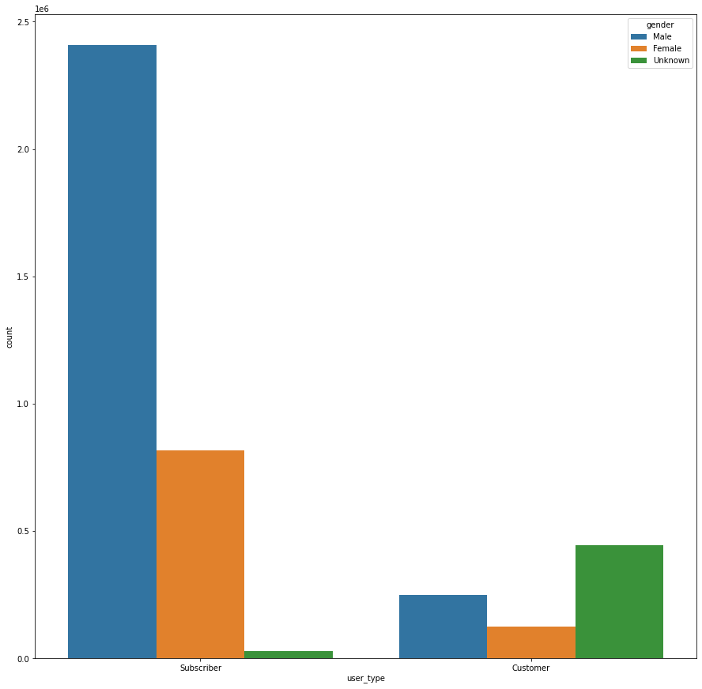

```python
# user_type vs gender
fig = plt.figure(figsize=(15, 15))
ax = fig.add_axes([.125, .125, .775, .755])
sb.countplot(data=clean_df, x='user_type', hue='gender');
```

**Intersting observation, the male to female ratio in subscribers group are more than the same in the customers group, and customers who didn't report their gender is nearly equal to the sum of both genders in customers group unlike subscribers who tend to report their gender**

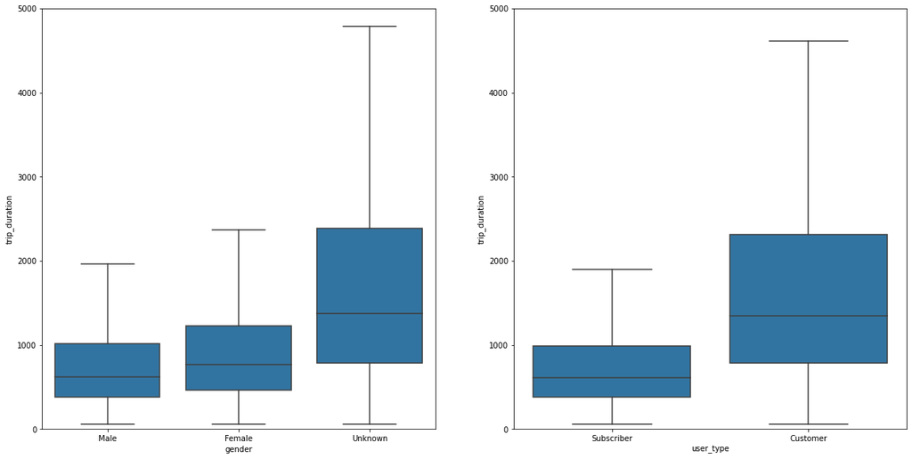

```python
# gender vs trip_duration and user_type vs trip_duration
plt.figure(figsize = (20, 10))

plt.subplot(1, 2, 1)
sb.boxplot(data=clean_df, x='gender', y='trip_duration', showfliers = False, color=base_color);
plt.ylim(0, 5000);

plt.subplot(1, 2, 2)
sb.boxplot(data=clean_df, x='user_type', y='trip_duration', showfliers = False, color=base_color);
plt.ylim(0, 5000);
```

- **on the left plot, Male users have the smallest trips duration range while Unknown gender has the largest and females lies in between**
- **On the right side, interestingly, the customers almost has the same boxplot of the users with unknown gender**

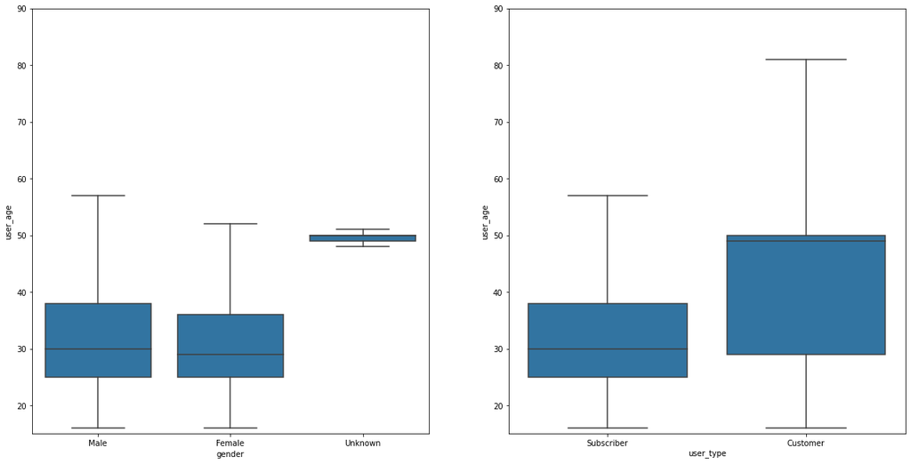

```python
# gender vs user_age and user_type vs user_age
plt.figure(figsize = (20, 10))

plt.subplot(1, 2, 1)
sb.boxplot(data=clean_df, x='gender', y='user_age', showfliers = False, color=base_color);
plt.ylim(15, 90);

plt.subplot(1, 2, 2)
sb.boxplot(data=clean_df, x='user_type', y='user_age', showfliers = False, color=base_color);
plt.ylim(15, 90);
```

**The median age for both males and females is around 30 years old that is corresponing to the median age of subscribers, while for uknown users, it's around 50 years old which corresponds to the median age of customers**

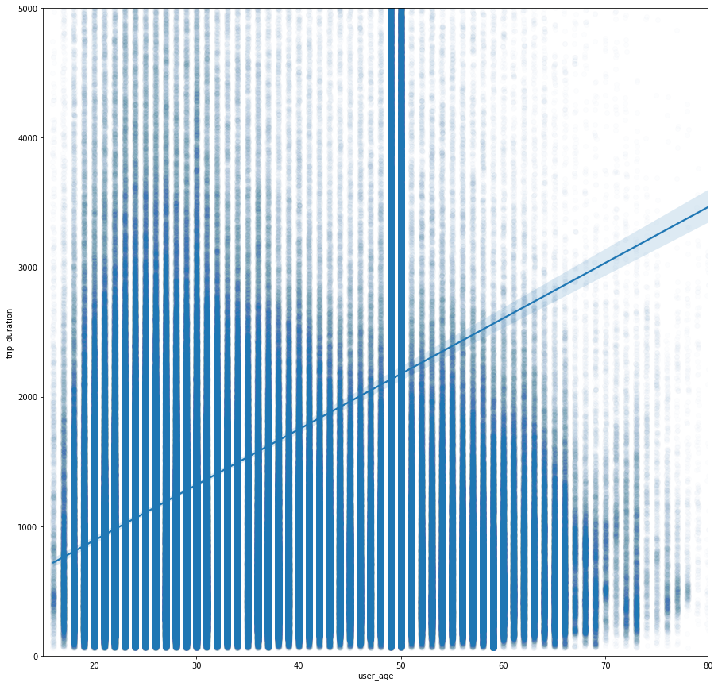

```python
# user_age vs trip_duration
fig = plt.figure(figsize=(15, 15))
ax = fig.add_axes([.125, .125, .775, .755])
sb.regplot(data=clean_df, x='user_age', y='trip_duration', scatter_kws={'alpha':0.01}, x_jitter=0.1);
plt.xlim(15, 80);
plt.ylim(0, 5000);
```

**The trip duration and user age has a positive correlation**

### Observed relationships of other features

> - In general, subscribers constitutes the vast majority of users with male user more than females, but users in customers group tend NOT to mention their gender.

## Multivariate Exploration

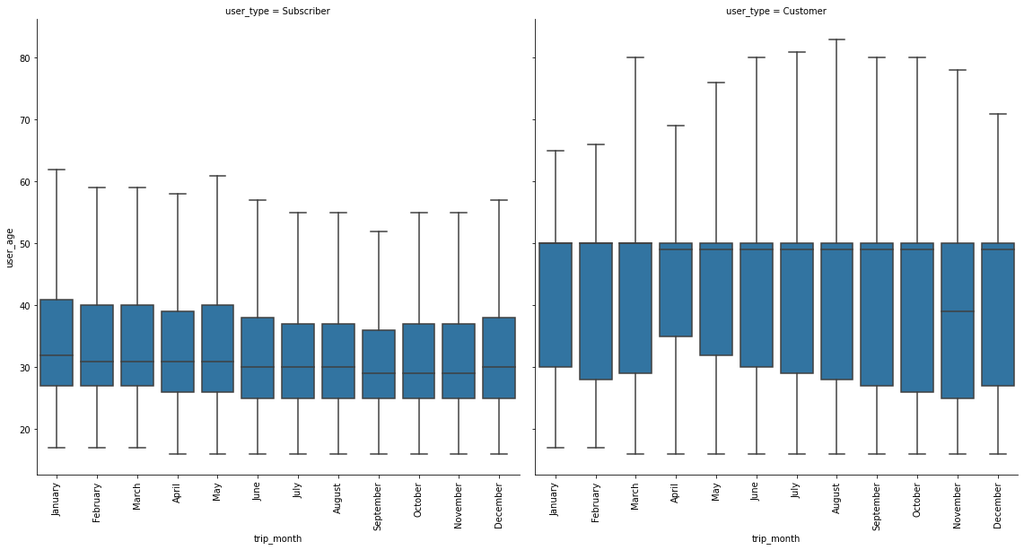

```python
# user_type vs trip_month vs user_age
g = sb.FacetGrid(data = clean_df, col = 'user_type', size=8);
g.map(sb.boxplot, 'trip_month', 'user_age', showfliers = False);
for ax in g.axes.flat:
    for label in ax.get_xticklabels():
        label.set_rotation(90)
```

**While there is a consistency in the median and ranges of age of the subscriber group in different months with median lies around age of 30, the customer group has higher medians and wider ranges with medians lies around 50 years old in all months except November which lies nearly at 40 years old**

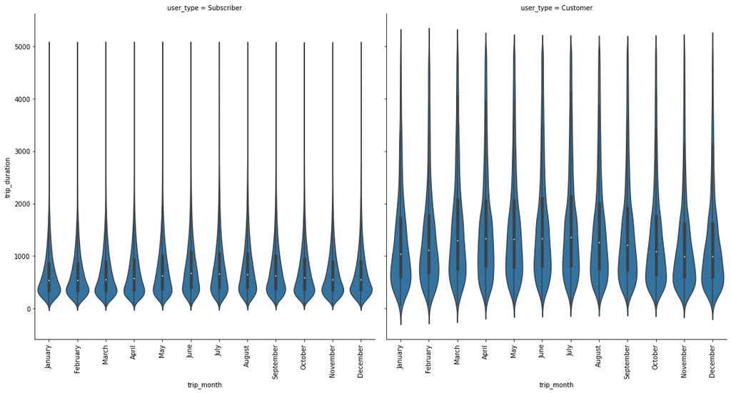

```python
# user_type vs trip_month vs trip_duration

trimmed_duration_df = clean_df[clean_df.trip_duration <= 5000]

g = sb.FacetGrid(data = trimmed_duration_df, col = 'user_type', size=8);
g.map(sb.violinplot, 'trip_month', 'trip_duration');
for ax in g.axes.flat:
    for label in ax.get_xticklabels():
        label.set_rotation(90)
```

**Users in subscriber group tend to have consistent trip durations over months, but in the customer group there is some variability in the trip durations from month to month with wider range and higher values**

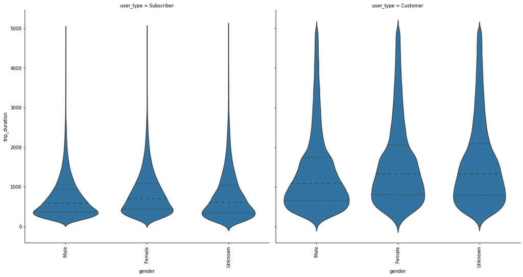

```python
# user_type vs gender vs trip_duration
trimmed_duration_df = clean_df[clean_df.trip_duration <= 5000]

g = sb.FacetGrid(data = trimmed_duration_df, col = 'user_type', size=8);
g.map(sb.violinplot, 'gender', 'trip_duration', inner = 'quartile');
for ax in g.axes.flat:
    for label in ax.get_xticklabels():
        label.set_rotation(90)
```

**Users in the subscriber group show tendency towards shorter trip durations with more males than females and unkown users, on the other hand users in the customer group tend to have more trips duration**

### Observed relationships

> Over months, subscribers showed consistency in their median ages and durations of trips they made, while customers have higher age medians and wider ranges and showed tendency towards higher trips durations.

### Surprising interaction

> On November, the median customers ages dropped from around 50 to around 40 years old, I think this is interesting and should be invistigated further to know the cause.